# Statistička analiza podataka - Projekt Analiza čimbenika rizika za srčane bolesti

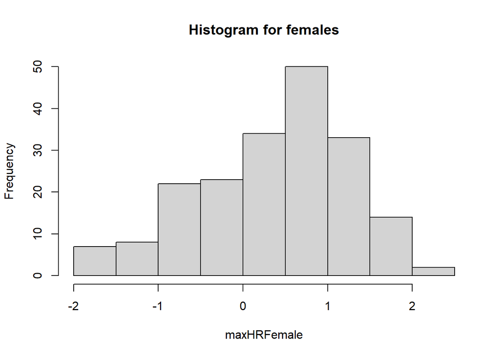

```r
hist(maxHRFemale, main = "Histogram for females")
```

Vidimo kako se podatci ne ravnaju savršeno po normalnoj razdiobi na repovima ali sličnost je dovoljno velika da bi mogli nastaviti s provođenjem testa (mala odstupanja od normalne razdiobe neće utjecati na rezultate zato što je T-test robusan na normalnost podataka).

Nakon što smo utvrdili nezavisnost i normalnost podataka, provodimo F-test kako bismo utvrdili jesu li varijance jednake ili različite.

```r
var(maxHRMale)
```

```
## [1] 1.020437
```

```r
var(maxHRFemale)
```

```
## [1] 0.7572015
```

```r
var.test(maxHRMale, maxHRFemale)
```

```
##
##  F test to compare two variances
##
## data:  maxHRMale and maxHRFemale
## F = 1.3476, num df = 724, denom df = 192, p-value = 0.01245
## alternative hypothesis: true ratio of variances is not equal to 1
## 95 percent confidence interval:
##  1.067533 1.676004
## sample estimates:
## ratio of variances
##           1.347643
```

Opet vidimo kako je p-vrijednost manja od alfa = 5% pa zaključujemo da su varijance različite. Sada znamo da trebamo koristiti T-test za dva uzorka s različitim varijancama.

```r
t.test(maxHRMale, maxHRFemale, var.equal = FALSE)
```

```
##
##  Welch Two Sample t-test
##
## data:  maxHRMale and maxHRFemale
## t = -6.3555, df = 342.77, p-value = 6.621e-10
## alternative hypothesis: true difference in means is not equal to 0
## 95 percent confidence interval:
##  -0.6076397 -0.3204219
## sample estimates:
##   mean of x   mean of y
## -0.09755767  0.36647312
```

Iz rezultata vidimo kako je p-vrijednost značajno manja od alfa = 5% pa zaključujemo da postoji razlika u maksimalnom broju otkucaja srca između muškaraca i žena.

## 5. pitanje

# Postoji li zavisnost između spola i pojave srčanih bolesti?

H0: spol i pojava srčanih bolesti su nezavisni H1: postoji zavisnost spola i pojave srčanih bolesti

```r
data_copy = data.frame(data);
tracemem(data)==tracemem(data_copy);
```

```
## [1] FALSE
```

```r
untracemem(data_copy);
```

```r
tbl_heart_disease = table(data_copy$Sex,
            data_copy$HeartDisease)
tbl_heart_disease
```

```
##
##       0   1
##   0 143  50
##   1 267 458
```

```r
added_margins_tbl_heart_disease = addmargins(tbl_heart_disease)
print(added_margins_tbl_heart_disease)
```

```
##
##         0   1 Sum
##   0   143  50 193
##   1   267 458 725
##   Sum 410 508 918
```

```r
for (col_names in colnames(added_margins_tbl_heart_disease)){
  for (row_names in rownames(added_margins_tbl_heart_disease)){
    if (!(row_names == 'Sum' | col_names == 'Sum') ){
      cat('Očekivane frekvencije za razred ',col_names,'-',row_names,': ',(added_margins_tbl_heart_disease[row_names,'Sum'] * added_margins_tbl_heart_disease['Sum',col_names]) / added_margins_tbl_heart_disease['Sum','Sum'],'\n')
    }
  }
}
```

```
## Očekivane frekvencije za razred  0 - 0 :  86.19826
## Očekivane frekvencije za razred  0 - 1 :  323.8017
## Očekivane frekvencije za razred  1 - 0 :  106.8017
## Očekivane frekvencije za razred  1 - 1 :  401.1983
```

```r
chisq.test(tbl_heart_disease, correct=F)
```

```
##
##  Pearson's Chi-squared test
##
## data:  tbl_heart_disease
## X-squared = 85.646, df = 1, p-value < 2.2e-16
```

Vidimo da je p-vrijednost jako mala što znači da odbacujemo hipotezu H0 u korist H1 koja tvrdi da postoji zavisnost između pojave srčanih bolesti i spola.